# Handson for `tidyverse`

Author

Kazuharu Yanagimoto

Published

January 11, 2023

In this exercise, we are going to see a relationship between **fertility rate** and **male’s unpaid work**.

Both data is available in the World Bank Data:

- [Fertility rate](https://data.worldbank.org/indicator/SP.DYN.TFRT.IN)
- [Proportion of time spent on unpaid domestic and care work, male](https://data.worldbank.org/indicator/SG.TIM.UWRK.MA)

You can load them by the `WDI` package.

```r
library(tidyverse)
library(WDI)

fertility <- WDI(indicator = "SP.DYN.TFRT.IN", start = 2010, end = 2019) |>
  rename(fertility = "SP.DYN.TFRT.IN")
unpaid_male <- WDI(indicator = "SG.TIM.UWRK.MA", start = 2010, end = 2019) |>
  rename(hour_unpaid = "SG.TIM.UWRK.MA")
```

**Quarto Notebook Cache**

If you like to solve exercises by compiling the notebook, set `cache: true` in the top yaml.

## `dplyr` & `tidyr`

**Q1 `glimpse`**

Look through the data. Check

- What type of values are in the `country` column
- How many `NA` values are in the data

```r
fertility |> glimpse()
```

```
Rows: 2,660
Columns: 5
$ country   <chr> "Africa Eastern and Southern", "Africa Eastern and Southern"…
$ iso2c     <chr> "ZH", "ZH", "ZH", "ZH", "ZH", "ZH", "ZH", "ZH", "ZH", "ZH", …
$ iso3c     <chr> "AFE", "AFE", "AFE", "AFE", "AFE", "AFE", "AFE", "AFE", "AFE…
$ year      <int> 2019, 2018, 2017, 2016, 2015, 2014, 2013, 2012, 2011, 2010, …
$ fertility <dbl> 4.482899, 4.527707, 4.570410, 4.615671, 4.677619, 4.739863, …
```

```r
unpaid_male |> glimpse()
```

```
Rows: 2,660
Columns: 5
$ country     <chr> "Africa Eastern and Southern", "Africa Eastern and Souther…
$ iso2c       <chr> "ZH", "ZH", "ZH", "ZH", "ZH", "ZH", "ZH", "ZH", "ZH", "ZH"…
$ iso3c       <chr> "AFE", "AFE", "AFE", "AFE", "AFE", "AFE", "AFE", "AFE", "A…
$ year        <int> 2019, 2018, 2017, 2016, 2015, 2014, 2013, 2012, 2011, 2010…
$ hour_unpaid <dbl> NA, NA, NA, NA, NA, NA, NA, NA, NA, NA, NA, NA, NA, NA, NA…
```

**Q2 `filter`**

Let’s focus only on OECD countries. Using the following vector `oecd`, choose only OECD-member countries.

```r
#remotes::install_github("caldwellst/whotilities")
oecd <- whoville::oecd_member_states()
```

```r
fertility_oecd <- fertility |>
  filter(iso3c %in% oecd)

unpaid_male_oecd <- unpaid_male |>
  filter(iso3c %in% oecd)
```

**Q3 `group_by` & `summarize`**

Now, we want to have a data point for each country. Considering the data, compute

- Mean of fertility rate by country
- Latest data point in `unpaid_male` of each country (use `top_n()`)

I know the second one is tough. See the answer if you want.

```r
mean_fertility <- fertility_oecd |>
  group_by(country) |>
  summarize(fertility = mean(fertility, na.rm = TRUE))

mean_fertility
```

```
# A tibble: 37 × 2
   country   fertility
   <chr>         <dbl>
 1 Australia      1.82
 2 Austria        1.47
 3 Belgium        1.72
 4 Canada         1.58
 5 Chile          1.71
 6 Colombia       1.87
 7 Czechia        1.57
 8 Denmark        1.74
 9 Estonia        1.60
10 Finland        1.64
# … with 27 more rows
```

```r
latest_unpaid <- unpaid_male_oecd |>
  filter(!is.na(hour_unpaid)) |>
  group_by(country) |>
  top_n(n = 1, wt = year)

latest_unpaid
```

```
# A tibble: 26 × 5
# Groups:   country [26]
   country  iso2c iso3c  year hour_unpaid
   <chr>    <chr> <chr> <int>       <dbl>
 1 Belgium  BE    BEL    2013       10.1
 2 Canada   CA    CAN    2016        9.58
 3 Chile    CL    CHL    2015        9.85
 4 Colombia CO    COL    2017        2.93
 5 Estonia  EE    EST    2010       10.8
 6 Finland  FI    FIN    2010       10.5
 7 France   FR    FRA    2010        9.49
 8 Germany  DE    DEU    2013       10.4
 9 Greece   GR    GRC    2014        7.01
10 Hungary  HU    HUN    2010        7.98
# … with 16 more rows
```

**Q4 `left_join()`**

Merge the two data frames you got in the last question.

```r
data  <- mean_fertility |>
  left_join(latest_unpaid, by = "country")

data
```

```
# A tibble: 37 × 6
   country   fertility iso2c iso3c  year hour_unpaid
   <chr>         <dbl> <chr> <chr> <int>       <dbl>
 1 Australia      1.82 <NA>  <NA>     NA       NA
 2 Austria        1.47 <NA>  <NA>     NA       NA
 3 Belgium        1.72 BE    BEL    2013       10.1
 4 Canada         1.58 CA    CAN    2016        9.58
 5 Chile          1.71 CL    CHL    2015        9.85
 6 Colombia       1.87 CO    COL    2017        2.93
 7 Czechia        1.57 <NA>  <NA>     NA       NA
 8 Denmark        1.74 <NA>  <NA>     NA       NA
 9 Estonia        1.60 EE    EST    2010       10.8
10 Finland        1.64 FI    FIN    2010       10.5
# … with 27 more rows
```

## `ggplot2`

**Q5 `geom_point()`**

Plot a scatter plot of male hours of unpaid work and fertility rate. To make it better, try

- Fit a linear line
- Change the coordinates
- Pick another theme

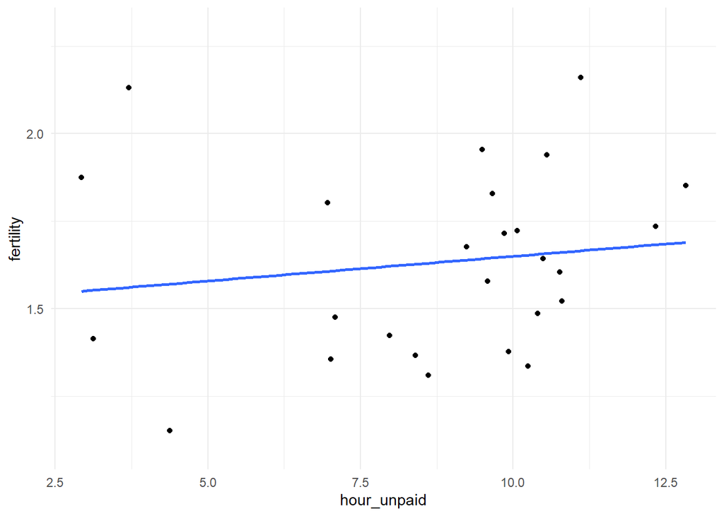

```r
data |>
  ggplot(aes(x = hour_unpaid, y = fertility)) +
  geom_point() +
  stat_smooth(formula = 'y ~ x',
              method = "lm", se = FALSE) +
  coord_cartesian(ylim = c(1.1, 2.3)) +
  theme_minimal()
```

**Q6 (Extra) `ggrepel::geom_text_repel()`**

Put country labels on data points. It is known that `ggrepel::geom_text_repel()` works better than the original `geom_text()`.

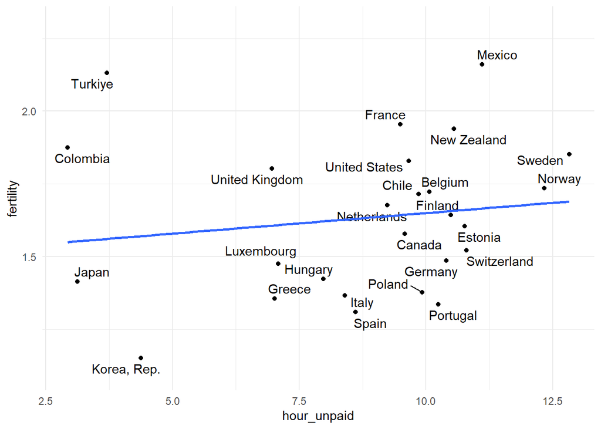

```r
data |>
  ggplot(aes(x = hour_unpaid, y = fertility, label = country)) +
  geom_point() +
  ggrepel::geom_text_repel() +
  stat_smooth(formula = 'y ~ x',
              method = "lm", se = FALSE) +
  coord_cartesian(ylim = c(1.1, 2.3)) +
  theme_minimal()
```